# Econometria II

Mestrado em Administração  
Aula 6

Prof. Washington Santos da Silva

IFMG - Campus Formiga

8 de abril de 2026

## Na aula anterior

**Tópicos**

- Estacionariedade
- Processo Ruído Branco
- Processo Autorregressivo (AR)
- Processo de Médias Móveis (MA)
- Processo Autorregressivo de Médias Móveis (ARMA)
- FAC e FACP de Processos AR, MA e ARMA
- Metodologia de Box e Jenkins (1970)

## Nesta aula

**Tópicos**

- Descrição dos Pacotes utilizados
- `tsibble`: estrutura de dados para séries temporais no formato tidy
- Modelos ARIMA e SARIMA
- Metodologia de Box e Jenkins (1970): modelos SARIMA
- Continuação: Avaliação da acurácia de previsões
- Aplicação
- Exercício

# Pacotes utilizados nesta aula

## Pacotes R

**O que mudou — e o que permanece**

Na aula anterior, usamos o pacote `forecast`, que trabalha com objetos `ts` e funções como `Arima()` e `auto.arima()`.

Nesta aula, adotamos o ecossistema [**tidyverts**](https://tidyverts.org/), que oferece:

- sintaxe unificada com *pipe*: `model()` → `forecast()` → `accuracy()`;
- integração direta com o `tidyverse` (`filter()`, `mutate()`, `select()`);
- alinhamento com o livro de Hyndman e Athanasopoulos (2021) e com a prática atual em R.

A **lógica estatística** — identificação, estimação, diagnóstico, previsão — permanece exatamente a mesma. Apenas as ferramentas computacionais mudam.

## Pacotes R

**O ecossistema [tidyverts](https://tidyverts.org/)**

Nesta aula, usamos um conjunto integrado de pacotes para séries temporais:

- **`tsibble`**: representa dados de séries temporais em formato *tidy*, oferecendo uma alternativa mais moderna à estrutura baseada em objetos `ts`.
- **`feasts`**: análise exploratória e diagnóstico — `gg_tsdisplay()`, `gg_tsresiduals()`, `ljung_box`.
- **`fable`**: estimação de modelos — `ARIMA()`, `ETS()`, `SNAIVE()`, entre outros.
- **`fabletools`**: infraestrutura de modelagem — `model()`, `forecast()`, `accuracy()`, `glance()`, `augment()`.
- **`fpp3`**: reúne os dados do livro de Hyndman e Athanasopoulos (2021) e, ao ser carregado, ativa todos os pacotes acima.

## Funções

**Glossário de Funções**

- `ggplot2::autoplot()`  
  para visualizar rapidamente séries temporais e previsões.
- `feasts::gg_tsdisplay()`  
  para exibir, em conjunto, a série, a FAC e a FACP, o que ajuda na etapa de identificação.
- `diff()`  
  função clássica do R para calcular diferenças em objetos de séries temporais do tipo `ts`.
- `fabletools::difference()`  
  função do ecossistema `fpp3`, útil para aplicar diferenciação em séries no formato `tsibble`.
- `fabletools::model()`  
  para ajustar modelos de séries temporais no ecossistema `fable`.
- `fable::ARIMA()`  
  para especificar e estimar modelos ARIMA e SARIMA.
- `generics::glance()`  
  para resumir medidas de ajuste, como AICc e BIC, e comparar modelos.
- `fabletools::augment()`  
  para extrair resíduos e outras saídas do modelo ajustado.
- `feasts::features(..., feasts::ljung_box)`  
  para aplicar o teste de Ljung-Box aos resíduos.
- `feasts::gg_tsresiduals()`  
  para produzir gráficos de diagnóstico dos resíduos.
- `fabletools::forecast()`  
  para gerar previsões a partir dos modelos ajustados.

# Pacote tsibble

## Pacote e Estrutura de Dados

**A estrutura de uma `tsibble`**

- O pacote `tsibble` introduziu uma estrutura de mesmo nome para armazenar dados de séries temporais.
- Uma `tsibble` é uma estrutura de dados para representar séries temporais com 3 componentes:

| Componente | Papel | Exemplo em `us_employment` |
| --- | --- | --- |
| **Índice** (*index*) | Coluna de tempo que ordena as observações | `Month` |
| **Chave** (*key*) | Identifica cada série dentro da tabela | `Series_ID` |
| **Medidas** (*measures*) | Variáveis numéricas de interesse | `Employed` |

- Ao imprimir uma `tsibble`, R informa o índice, a chave e o intervalo temporal no cabeçalho.
- Observe também que a coluna `Month` aparece com a classe `<mth>` (`yearmonth`) — um tipo de data específico da `tsibble` que armazena ano e mês.

## A estrutura de um `tsibble`

```r
# Exibe as primeiras linhas de us_employment
# Observe no cabeçalho: o índice (Month), a chave (Series_ID) e o
# intervalo [1M] (mensal)
us_employment |> head(8)
```

```
# A tsibble: 8 x 4 [1M]
# Key:       Series_ID [1]
     Month Series_ID     Title         Employed
     <mth> <chr>         <chr>            <dbl>
1 1939 Jan CEU0500000001 Total Private    25338
2 1939 Feb CEU0500000001 Total Private    25447
3 1939 Mar CEU0500000001 Total Private    25833
4 1939 Apr CEU0500000001 Total Private    25801
5 1939 May CEU0500000001 Total Private    26113
6 1939 Jun CEU0500000001 Total Private    26485
7 1939 Jul CEU0500000001 Total Private    26481
8 1939 Aug CEU0500000001 Total Private    26848
```

## A estrutura de um `tsibble`

**Extraindo componentes temporais do índice**

As colunas de índice usam classes especiais que representam o período da série:

| Classe | Representa | Aparece como |
| --- | --- | --- |
| `yearmonth` | ano-mês | `2001 jan` |
| `yearquarter` | ano-trimestre | `1992 Q1` |
| `Date` | data diária | `2015-01-02` |

Essas classes permitem usar funções do pacote `lubridate` para extrair partes da data:

| Função | O que extrai | Exemplo |
| --- | --- | --- |
| `year(Month)` | ano | `2001`, `2019` |
| `month(Month)` | mês (1–12) | `3` (março) |
| `quarter(Quarter)` | trimestre (1–4) | `2` (abr–jun) |

Essas funções aparecem ao longo de toda a aula. Por exemplo:

- `filter(year(Month) > 2000)` — seleciona observações a partir de 2001;
- `filter(year(Quarter) <= 2007)` — cria um conjunto de treino até 2007.

## `tsibble` e as funções do `dplyr`

**Compatibilidade com o `dplyr`**

- As funções `filter()`, `mutate()` e `select()` funcionam em `tsibbles` da mesma forma que em `tibbles` comuns.
- A única diferença é que o resultado **preserva automaticamente a coluna de índice**, mesmo que ela não seja incluída explicitamente no `select()`.

# Modelos ARIMA e SARIMA

## Modelo ARIMA

**Descrição**

Um modelo **ARIMA($p,d,q$)** é apropriado quando a série original precisa ser **diferenciada** $d$ vezes para se tornar aproximadamente estacionária e, após isso, pode ser descrita por um modelo **ARMA($p,q$)**.

Em notação compacta:

$$\phi(B)(1-B)^d y_t = \mu + \theta(B)\varepsilon_t,$$

em que:

- $p$: ordem da parte autorregressiva (**AR**);
- $d$: número de diferenças simples necessárias;
- $q$: ordem da parte de médias móveis (**MA**);
- $B$: operador de defasagem;
- $\varepsilon_t$: erro aleatório, assumido como ruído branco.

Equivalentemente, podemos escrever:

$$\Delta^d y_t = \mu + \phi_1 \Delta^d y_{t-1} + \cdots + \phi_p \Delta^d y_{t-p}
+ \theta_1 \varepsilon_{t-1} + \cdots + \theta_q \varepsilon_{t-q} + \varepsilon_t.$$

Em resumo, o ARIMA combina:

- **diferenciação**, para remover tendência estocástica;
- **termos AR**, para capturar dependência nos valores passados;
- **termos MA**, para capturar dependência nos erros passados.

## Quando o ARIMA não sazonal não basta?

**Motivação para a diferenciação sazonal e o SARIMA**

Em muitas séries temporais, também pode haver um padrão sistemático em **defasagens sazonais**, como:

- $12, 24, 36, \ldots$ em dados mensais;
- $4, 8, 12, \ldots$ em dados trimestrais.

Nesses casos, um ARIMA não sazonal pode ser insuficiente.

Uma forma inicial de tratar esse problema é aplicar a **diferença sazonal**:

$$\Delta_m y_t = y_t - y_{t-m},$$

em que $m$ representa o período sazonal.

- Se a série for mensal e o padrão sazonal se repetir a cada ano, então m = 12.
- Se a série for trimestral e o padrão sazonal se repetir a cada ano, então m = 4.

Quando a série apresenta dependência sazonal, passamos do modelo **ARIMA** para o **SARIMA**, que amplia o modelo ao incluir:

- diferenciação sazonal;
- termos autorregressivos sazonais;
- termos de médias móveis sazonais.

## Exemplo: diferença sazonal

**Série `a10`**

A série `a10` registra as vendas mensais de medicamentos antidiabéticos na Austrália.

Ela é útil para ilustrar um caso em que:

- há **forte sazonalidade**;
- a variabilidade cresce com o nível da série;
- uma transformação logarítmica, seguida de **diferença sazonal**, ajuda a obter uma série mais próxima da estacionaridade.

## Exemplo: diferença sazonal

```r
cbind(
  "Vendas (milhões)" = fpp2::a10,
  "Log das vendas" = log(fpp2::a10),
  "Diferença sazonal do log" = diff(log(fpp2::a10), lag = 12)
) |>
  autoplot(facets = TRUE) +
  xlab("Ano") +
  ylab("") +
  ggtitle("Vendas mensais de medicamentos antidiabéticos na Austrália")
```

## Exemplo: diferença sazonal

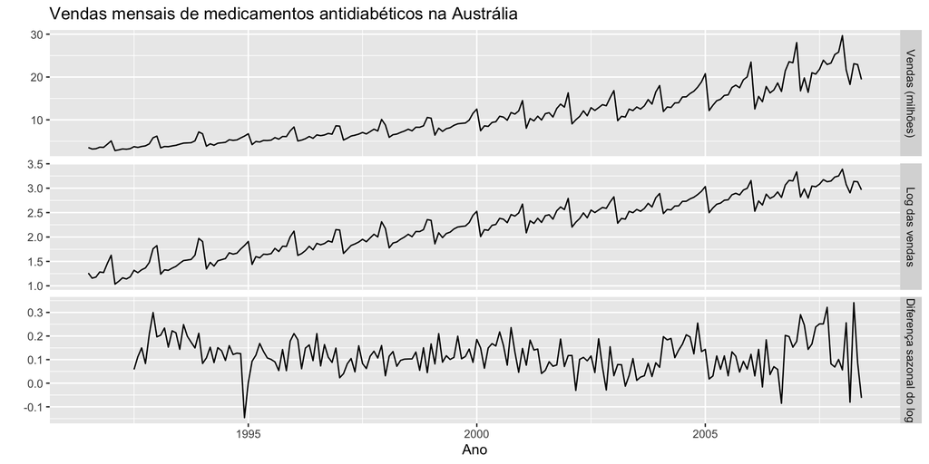

## Interpretação do gráfico

**Interpretação**

- No painel inferior, cada valor representa a diferença em relação ao mesmo mês do ano anterior.
- Se a sazonalidade for aproximadamente estável ao longo do tempo, essa operação tende a reduzir o padrão sazonal e pode aproximar a série de um comportamento estacionário.

## Exemplo: quando a diferença sazonal ainda não é suficiente

**Série `usmelec`**

A série `usmelec` contém a geração mensal de eletricidade nos Estados Unidos.

Neste exemplo, a diferença sazonal melhora bastante a série, mas ainda pode restar um componente de tendência. Nesses casos, pode ser necessário aplicar:

- uma **diferença sazonal**; e
- uma **primeira diferença simples**.

Esse procedimento é chamado de **dupla diferenciação**.

## Exemplo: quando a diferença sazonal ainda não é suficiente

```r
# combina as séries em colunas
cbind(
  "Bilhões de kWh" = fpp2::usmelec,
  "Log da série" = log(fpp2::usmelec),
  "Log com diferença sazonal" = diff(log(fpp2::usmelec), lag = 12),
  "Log com dupla diferenciação" = diff(diff(log(fpp2::usmelec), lag = 12), lag = 1)
) |>
  # gráficos das séries
  autoplot(facets = TRUE) +
  xlab("Ano") +
  ylab("") +
  ggtitle("Geração mensal de eletricidade nos EUA")
```

## Exemplo: quando a diferença sazonal ainda não é suficiente

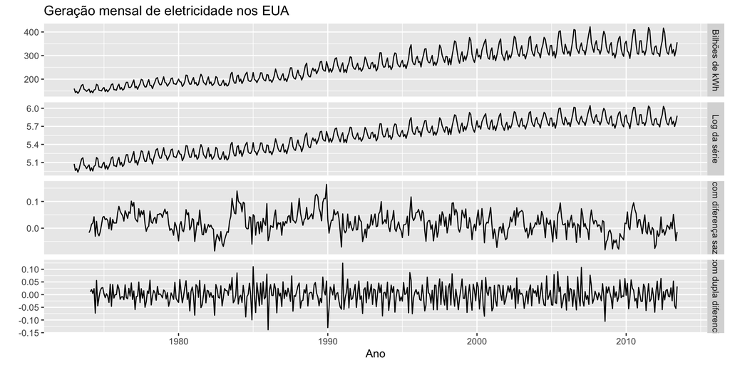

## Interpretação do gráfico

**Interpretação**

- O painel inferior sugere uma série mais estável em média, sem tendência aparente forte e com sazonalidade bastante reduzida.
- Esse tipo de inspeção visual ajuda a decidir valores plausíveis para:
  - $d$: ordem de diferenciação não sazonal;
  - $D$: ordem de diferenciação sazonal.

## Modelo SARIMA

**Motivação**

Os exemplos anteriores mostraram que, em séries sazonais, frequentemente é necessário:

- aplicar uma **diferença sazonal** para remover padrões que se repetem a cada $m$ períodos;
- e, em alguns casos, também uma **diferença simples** para remover tendência.

No entanto, diferenciar a série é apenas parte do problema.

## Modelo SARIMA

**Motivação**

Após tornar a série aproximadamente estacionária, ainda precisamos modelar a dependência serial remanescente, que pode ocorrer em dois níveis:

- **não sazonal**, em defasagens curtas, como 1, 2, 3, $\ldots$;
- **sazonal**, em defasagens múltiplas de $m$, como $m, 2m, 3m, \ldots$.

O modelo **SARIMA** amplia o ARIMA justamente para lidar, de forma conjunta, com esses dois tipos de dependência.

## Modelo SARIMA

**Notação e interpretação**

O modelo **SARIMA $(p,d,q)(P,D,Q)_m$** combina:

- uma parte **não sazonal** ARIMA$(p,d,q)$;
- uma parte **sazonal** $(P,D,Q)_m$, com período sazonal $m$.

Uma representação compacta é:

$$\Phi(B^m)\phi(B)(1-B)^d(1-B^m)^D y_t
=
\Theta(B^m)\theta(B)\varepsilon_t.$$

em que:

- $p$: ordem AR não sazonal;
- $d$: número de diferenças simples;
- $q$: ordem MA não sazonal;
- $P$: ordem AR sazonal;
- $D$: número de diferenças sazonais;
- $Q$: ordem MA sazonal;
- $m$: período sazonal;
- $B$: operador de defasagem;
- $\varepsilon_t$: ruído branco.

Em resumo:

- $(1-B)^d$ controla a **integração não sazonal**;
- $(1-B^m)^D$ controla a **integração sazonal**;
- $\phi(B)$ e $\theta(B)$ modelam a dinâmica **não sazonal**;
- $\Phi(B^m)$ e $\Theta(B^m)$ modelam a dinâmica **sazonal**.

## Modelo SARIMA

**Exemplo de leitura da notação**

No modelo SARIMA$(2,1,0)(1,1,1)_{12}$:

- há 2 termos AR não sazonais;
- 1 diferença simples;
- 0 termos MA não sazonais;
- 1 termo AR sazonal;
- 1 diferença sazonal;
- 1 termo MA sazonal;
- e sazonalidade de período 12.

## Modelo SARIMA

**Exemplo de estrutura: SARIMA$(1,1,1)(1,1,1)_4$**

A figura abaixo ilustra a estrutura de um modelo SARIMA$(1,1,1)(1,1,1)_4$.

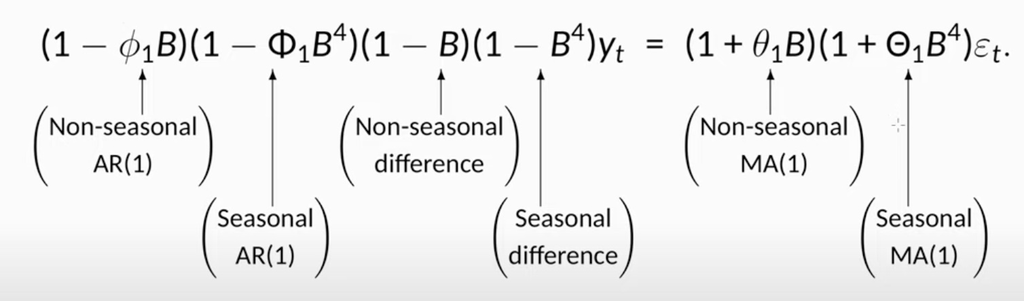

Este exemplo usa uma série trimestral apenas para ilustrar a estrutura geral do modelo SARIMA.

Nesse caso:

- a parte **não sazonal** é ARIMA$(1,1,1)$;
- a parte **sazonal** é $(1,1,1)_4$;
- o período sazonal é $m = 4$, como ocorre em séries trimestrais com sazonalidade anual.

A principal ideia é que o modelo combina, ao mesmo tempo:

- dependência de curto prazo;
- diferenciação para induzir estacionaridade;
- e dependência sazonal em múltiplos de 4 períodos.

## Modelo SARIMA

**Como a FAC e FACP ajudam na identificação?**

Em séries com sazonalidade, a identificação do modelo deve considerar também os **lags sazonais**.

Se os dados são mensais, por exemplo, os lags sazonais típicos são:

- $12, 24, 36, \ldots$

Ao inspecionar a FAC e a FACP, buscamos sinais de dependência em:

- **lags não sazonais**, como 1, 2, 3, $\ldots$;
- **lags sazonais**, como $m, 2m, 3m, \ldots$

## Modelo SARIMA

**Como a FAC e FACP ajudam na identificação?**

Alguns padrões úteis são:

- **SARIMA$(0,0,0)(0,0,1)_{12}$**:

tende a apresentar um pico significativo na **FAC** no lag 12, enquanto a **FACP** exibe decaimento nos lags sazonais.

- **SARIMA$(0,0,0)(1,0,0)_{12}$**:

tende a apresentar um pico significativo na **FACP** no lag 12, enquanto a **FAC** exibe decaimento nos lags sazonais.

## Modelo SARIMA

**Outros critérios**

Na prática, a FAC e a FACP ajudam a propor **modelos candidatos**, mas a escolha final também deve levar em conta:

- critérios de informação, como AICc e BIC;
- diagnóstico dos resíduos;
- e, quando pertinente, desempenho preditivo.

# Metodologia de Box e Jenkins (1970): modelos SARIMA

## Metodologia de Box & Jenkins

**Exemplo com `us_employment`**

Usaremos a série `us_employment`, do pacote `fpp3` (Hyndman e Athanasopoulos, 2021), que contém séries mensais de emprego nos Estados Unidos para diferentes setores da economia.

Nesta aula, consideraremos o setor **Leisure and Hospitality** no período de janeiro de 2001 em diante.

O objetivo é ilustrar as etapas da metodologia de **Box & Jenkins**:

1. visualizar a série e compreender sua dinâmica;
2. buscar estacionaridade com transformações e diferenciação;
3. propor modelos candidatos com base na FAC e na FACP;
4. estimar e comparar modelos;
5. diagnosticar os resíduos;
6. e, se o modelo for adequado, gerar previsões.

Neste exemplo, nosso foco principal será a construção de um modelo **SARIMA** para uma série mensal com forte sazonalidade.

## Etapa 1: identificação — visualização inicial da série

```r
# Filtra a série de emprego do setor de lazer e hospitalidade
# a partir de 2001, converte o nível de emprego para milhões
# e mantém apenas as colunas relevantes para a análise
leisure <- us_employment |>
  filter(Title == "Leisure and Hospitality", year(Month) > 2000) |>
  mutate(Employed = Employed / 1000) |>
  select(Month, Employed)

# visualiza a série, a fac e a facp
leisure |>
  gg_tsdisplay(
    plot_type = "partial",
    lag = 36
  )
```

## Etapa 1: identificação — visualização inicial da série

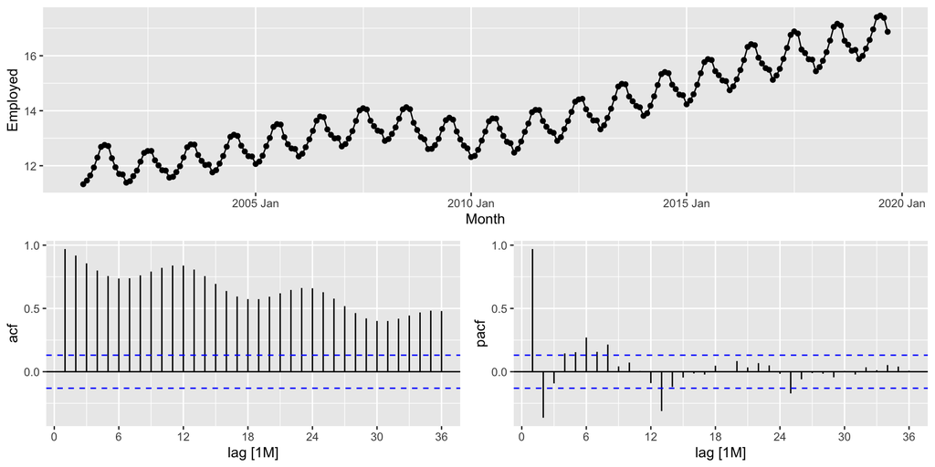

## Etapa 1: identificação — visualização inicial da série

**Leitura inicial do gráfico**

A série apresenta, de forma bastante clara:

- **tendência (crescente)**, isto é, aumento persistente no nível médio ao longo do tempo;
- **sazonalidade anual**, com um padrão que parece se repetir aproximadamente a cada 12 meses;
- e evidências de **não estacionaridade**.

Isso sugere que um modelo ARIMA não sazonal, aplicado diretamente à série original, provavelmente não será adequado.

## Etapa 1: identificação — após uma diferença sazonal

```r
# Visualiza a série após aplicar uma diferença sazonal de ordem 12
leisure |>
  gg_tsdisplay(
    difference(Employed, 12),
    plot_type = "partial",
    lag = 36
  ) +
  labs(
    title = "Série com uma diferença sazonal",
    y = ""
  )
```

## Etapa 1: identificação — após uma diferença sazonal

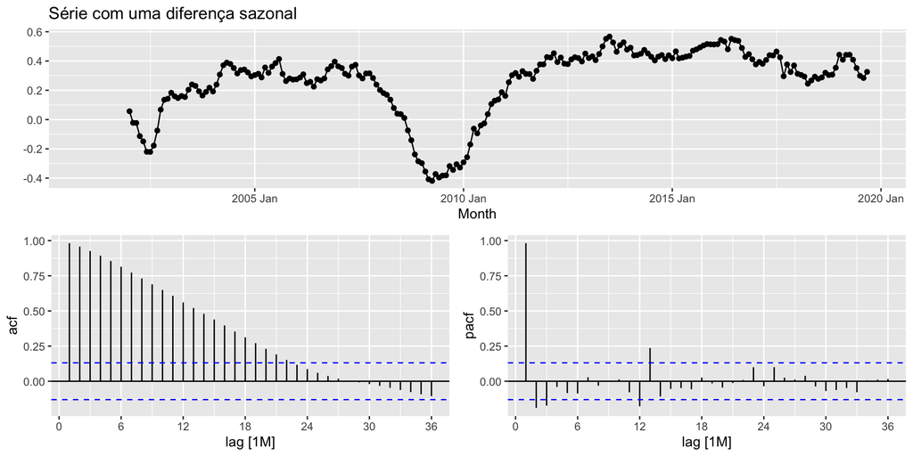

## Etapa 1: identificação — após uma diferença sazonal

**Interpretação**

Após aplicar uma diferença sazonal de ordem 12:

- a sazonalidade é reduzida de forma importante;
- porém a série ainda parece apresentar alguma **não estacionaridade**;
- por isso, uma única diferença sazonal pode não ser suficiente.

Quando isso ocorre, é natural considerar também uma **primeira diferença simples**.

## Etapa 1: identificação — após dupla diferenciação

```r
# Visualiza a série após aplicar:
# 1) uma diferença sazonal de ordem 12; e
# 2) uma primeira diferença simples
# O objetivo é remover tanto a sazonalidade quanto a tendência remanescente
leisure |>
  gg_tsdisplay(
    difference(Employed, lag = 12) |>
      difference(),
    plot_type = "partial",
    lag = 36
  ) +
  labs(
    title = "Série com dupla diferenciação",
    y = ""
  )
```

## Etapa 1: identificação — após dupla diferenciação

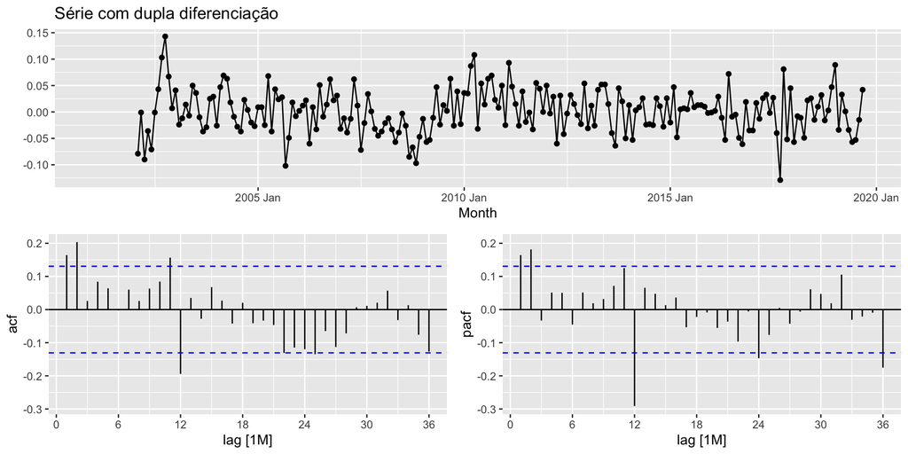

## Etapa 1: identificação — após dupla diferenciação

**Interpretação**

Após a dupla diferenciação, a série parece mais compatível com a hipótese de estacionaridade.

Além disso:

- a FAC e a FACP da série diferenciada passam a fornecer pistas mais úteis sobre ordens plausíveis para os componentes AR e MA;
- tanto na parte não sazonal quanto na parte sazonal do modelo.
- Esse é o ponto em que começamos a propor modelos candidatos.

## Etapa 1: identificação

**Propondo modelos candidatos**

Neste exemplo, uma leitura plausível é a seguinte:

#### Com base na FAC:

- um pico significativo em lag curto sugere a inclusão de um componente **MA não sazonal**;
- um pico significativo no lag sazonal 12 sugere a inclusão de um componente **MA sazonal**.

Isso motiva, por exemplo, o modelo:

$$\text{SARIMA}(0,1,2)(0,1,1)_{12}.$$

## Etapa 1: identificação

**Propondo modelos candidatos**

Outra leitura plausível é:

#### Com base na FACP

- picos relevantes em lags curtos podem sugerir componentes **AR não sazonais**;
- o comportamento nos lags sazonais ajuda a avaliar a presença de componentes **AR sazonais**.

Uma alternativa plausível é:

$$\text{SARIMA}(2,1,0)(0,1,1)_{12}.$$

## Etapa 1: identificação

**Observação importante**

A FAC e a FACP **não determinam sozinhas** o modelo final. Elas ajudam a propor **modelos candidatos**, que depois devem ser:

- estimados;
- comparados por critérios como **AICc** e **BIC**;
- e avaliados por meio do diagnóstico dos resíduos.

#### Seleção Automática

- Também é útil ajustar um modelo selecionado automaticamente, para compará-lo com os modelos sugeridos pela leitura da FAC e da FACP.
- No pacote `fable`, isso pode ser feito com `ARIMA()` usando uma busca mais ampla no espaço de modelos.

## Por que usamos o AICc?

**Do AIC ao AICc**

Na Aula 3, vimos o critério de informação de Akaike:

$$\text{AIC} = -2\ln(\hat{L}) + 2k$$

O **AICc** é uma correção para **amostras finitas**:

$$\text{AICc} = \text{AIC} + \frac{2k(k+1)}{T - k - 1}$$

em que $k$ é o número de parâmetros estimados e $T$ o tamanho da amostra.

- Quando $T$ é grande em relação a $k$, o termo de correção tende a zero e o AICc converge para o AIC.
- Quando $T$ é moderado — como é comum em séries temporais — o AIC tende a **selecionar modelos com parâmetros demais**. O AICc corrige esse viés.

Por isso, o pacote `fable` adota o AICc como critério padrão de seleção.

## Etapa 2: estimação e comparação inicial dos modelos

```r
# Ajusta três modelos candidatos para a série de emprego:
# 1) um modelo sugerido principalmente pela FAC;
# 2) um modelo alternativo sugerido pela FACP;
# 3) um modelo selecionado automaticamente
fit <- leisure |>
  model(
    # pdq(p, d, q): fixa a parte NÃO sazonal
    # PDQ(P, D, Q): fixa a parte SAZONAL
    arima012011 = ARIMA(Employed ~ pdq(0, 1, 2) + PDQ(0, 1, 1)),
    arima210011 = ARIMA(Employed ~ pdq(2, 1, 0) + PDQ(0, 1, 1)),
    # stepwise = FALSE: busca exaustiva (mais lenta, porém mais completa)
    # approx = FALSE: usa verossimilhança exata (mais precisa)
    auto = ARIMA(Employed, stepwise = FALSE, approx = FALSE)
  )

# Exibe os modelos ajustados
fit |> pivot_longer(everything(), names_to = "Modelo", values_to = "Especificacao")

# Resume medidas de ajuste e ordena os modelos por AICc
glance(fit) |>
  arrange(AICc) |>
  select(.model, AICc, AIC, BIC)
```

## Etapa 2: estimação e comparação inicial dos modelos

**O que observar nesta etapa?**

Após ajustar os modelos, devemos verificar principalmente:

- quais especificações produziram os menores valores de **AICc**;
- se as diferenças entre os critérios de informação são grandes ou pequenas;
- e se os modelos candidatos fazem sentido também do ponto de vista do diagnóstico dos resíduos.

Ou seja, nesta etapa ainda não escolhemos o modelo final apenas com base na FAC/FACP: agora começamos a combinar **identificação**, **estimação** e **comparação formal**.

## Etapa 2: resultados da estimação e seleção dos modelos

```
# A mable: 3 x 2
# Key:     Modelo [3]
  Modelo                  Especificacao
  <chr>                         <model>
1 arima012011 <ARIMA(0,1,2)(0,1,1)[12]>
2 arima210011 <ARIMA(2,1,0)(0,1,1)[12]>
3 auto        <ARIMA(2,1,0)(1,1,1)[12]>
```

```
# A tibble: 3 × 4
  .model       AICc   AIC   BIC
  <chr>       <dbl> <dbl> <dbl>
1 auto        -780. -780. -763.
2 arima210011 -776. -776. -763.
3 arima012011 -775. -775. -761.
```

## Etapa 2: resultados da estimação e seleção dos modelos

**Interpretação dos resultados**

Como o **AICc** deve ser **minimizado**, o modelo preferido entre os três modelos comparados foi:

$$\text{ARIMA}(2,1,0)(1,1,1)_{12},$$

selecionado automaticamente pela função `ARIMA()`.

Além disso, o modelo

$$\text{ARIMA}(2,1,0)(0,1,1)_{12}$$

apresentou valor de AICc muito próximo, o que é didaticamente importante, pois mostra que:

- a leitura da **ACF/PACF** levou a um modelo manual bastante competitivo;
- a seleção automática sugeriu um refinamento adicional na parte sazonal, com a inclusão de um termo AR sazonal.

No entanto, a escolha final do modelo ainda depende do **diagnóstico dos resíduos**.

## Etapa 2: interpretação do modelo preferido

**Observação**

É mais preciso dizer que o modelo

$$\text{ARIMA}(2,1,0)(1,1,1)_{12}$$

foi **preferido entre os modelos comparados** com base no **AICc**.

Evita-se, assim, afirmar que ele é o único modelo “melhor” em sentido absoluto, pois a avaliação final ainda deve considerar:

- o **diagnóstico dos resíduos**;
- a **parcimônia** do modelo;
- e, quando pertinente, o **desempenho preditivo**.

## Etapa 3: diagnóstico dos resíduos

**O que queremos verificar?**

Após estimarmos diversos modelos candidatos e selecionar um modelo, esperamos que os resíduos se comportem aproximadamente como **ruído branco**.

Isso significa, em termos práticos:

- média aproximadamente nula;
- variância aproximadamente constante;
- ausência de autocorrelação remanescente.

Os gráficos ajudam a identificar possíveis violações dessas condições antes de aplicarmos um teste formal.

## Etapa 3: diagnóstico gráfico dos resíduos

```r
# Produz gráficos diagnósticos para os resíduos do modelo automático:
# - resíduos ao longo do tempo
# - FAC dos resíduos
# - histograma/distribuição dos resíduos
fit |>
  select(auto) |>
  gg_tsresiduals(lag = 36)
```

## Etapa 3: diagnóstico gráfico dos resíduos

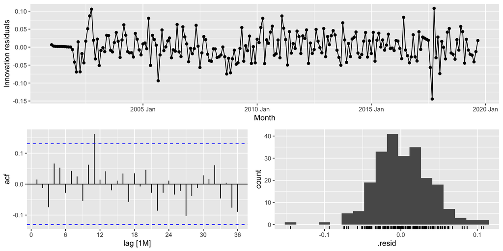

## Etapa 3: teste de Ljung-Box

**Teste formal de autocorrelação residual**

Como vimos, além da inspeção gráfica, podemos aplicar o teste de **Ljung-Box** aos resíduos do modelo selecionado.

A hipótese nula do teste é que os resíduos não apresentam autocorrelação até a defasagem escolhida.

Ao aplicar o teste, devemos ajustar os graus de liberdade para refletir o número de parâmetros autorregressivos e de médias móveis estimados no modelo selecionado.

Neste exemplo, como o modelo selecionado foi SARIMA$(2,1,0)(1,1,1)_{12}$, uma escolha coerente é `dof = 4`, pois o modelo possui 4 parâmetros AR/MA: $p = 2$ (AR não sazonal) + $P = 1$ (AR sazonal) + $Q = 1$ (MA sazonal).

## Etapa 3: teste de Ljung-Box

```r
# Aplica o teste de Ljung-Box aos resíduos do modelo selecionado
# lag = 24: testa autocorrelação até 24 defasagens
# dof = 4: graus de liberdade = nº de parâmetros AR/MA estimados
augment(fit) |>
  filter(.model == "auto") |>
  features(.innov, ljung_box, lag = 24, dof = 4)
```

```
# A tibble: 1 × 3
  .model lb_stat lb_pvalue
  <chr>    <dbl>     <dbl>
1 auto      16.6     0.680
```

## Etapa 3: teste de Ljung-Box

**Interpretação**

Como o valor-p do teste de Ljung-Box foi **0,680**, não rejeitamos a hipótese nula de ausência de autocorrelação residual até a defasagem considerada.

Assim, esse resultado é **compatível com resíduos semelhantes a ruído branco**, o que reforça a adequação do modelo ajustado.

Em conjunto com a análise gráfica dos resíduos, o teste sugere que o modelo:

$$\text{SARIMA}(2,1,0)(1,1,1)_{12}$$

capturou de forma adequada a dependência temporal remanescente da série.

## Previsão

**Do modelo ajustado à construção de previsões**

Após selecionar um modelo **SARIMA** e verificar que seus resíduos são compatíveis com ruído branco, podemos utilizá-lo para gerar previsões para períodos futuros.

Nesta etapa, porém, é importante distinguir duas coisas:

- **construir previsões** com um modelo ajustado;
- **avaliar a acurácia preditiva** dessas previsões.

Neste bloco, faremos apenas a primeira dessas tarefas.

O objetivo dos slides seguintes é **ilustrar** como o modelo selecionado pode ser usado para prever valores futuros e, ao mesmo tempo, **motivar** a próxima parte da aula, na qual discutiremos como avaliar a acurácia dessas previsões de forma adequada.

## Previsão

**Pergunta importante**

O código a seguir:

- gera previsões para os próximos 36 períodos;
- mantém apenas as previsões do modelo selecionado automaticamente;
- e exibe essas previsões em conjunto com a série observada.

No entanto, ele **não constitui, por si só, um experimento adequado de avaliação da acurácia preditiva**.

Por quê?

## Previsão

```r
# Gera previsões para 36 períodos à frente
# usando os modelos contidos em fit
forecast(fit, h = 36) |>

  # Mantém apenas as previsões do modelo automático
  filter(.model == "auto") |>

  # Exibe as previsões juntamente com os dados observados da série
  autoplot(leisure) +
  labs(
    title = "Emprego nos EUA: lazer e hospitalidade",
    y = "Número de pessoas (milhões)",
    x = "Ano"
  )
```

## Previsão

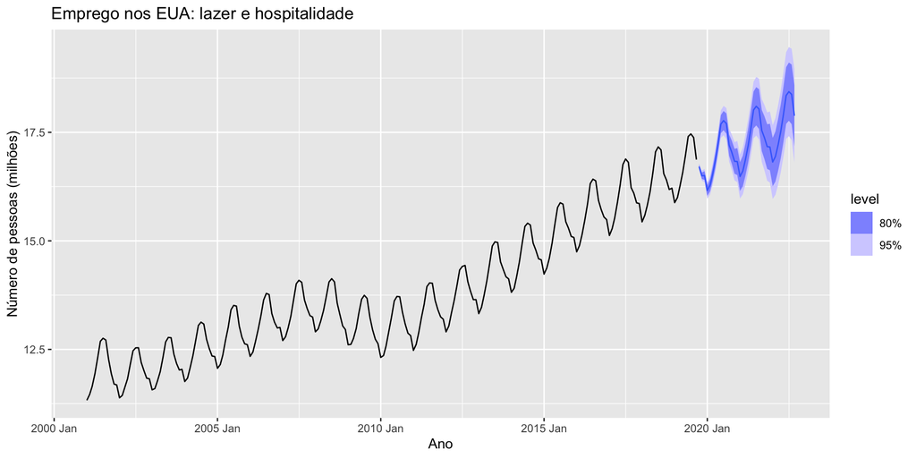

## Previsão

**O que esse gráfico nos mostra?**

Esse gráfico é útil para visualizar:

- as **previsões pontuais** do modelo;
- os **intervalos de previsão**;
- e a forma como o modelo projeta, para o futuro, o comportamento recente da série.

Mas essa visualização, sozinha, **não basta** para concluir que o modelo gera previsões precisas.

## Previsão

**Acurácia das Previsões**

As previsões parecem plausíveis e preservam o padrão sazonal projetado pelo modelo.

Mas isso ainda não responde à pergunta central:

- **quão precisas essas previsões realmente são?**

Para responder a essa pergunta, precisamos discutir procedimentos adequados de avaliação da **acurácia preditiva**, como:

- separação entre dados de **treino** e **teste**;
- geração de previsões para observações não usadas na estimação;
- e uso de medidas do erro de previsão.

É isso que faremos na próxima parte da aula.

## Retomando: resíduos vs. erros de previsão

**Relembrando da Aula 3**

Na Aula 3, vimos que:

- **Resíduos** medem o erro do modelo **dentro da amostra de treino**;
- **Erros de previsão** medem o erro em **dados não usados na estimação**.

O diagnóstico dos resíduos (etapa anterior) verifica se o modelo capturou a dependência temporal.

Mas resíduos pequenos **não garantem** previsões precisas.

Para avaliar a acurácia preditiva, precisamos de um **experimento fora da amostra**: separar treino/teste e calcular métricas como MAE, RMSE e MASE — conceitos que estudamos na Aula 3 e que agora aplicaremos ao contexto dos modelos ARIMA e SARIMA.

# Continuação: Avaliando a Acurácia de Previsões

## Conjuntos de Teste e Treinamento

**Revisão: Conceitos da Aula 3**

Antes de aplicar a avaliação de acurácia ao modelo SARIMA (exercício final), revisamos brevemente os conceitos centrais vistos na Aula 3.

- É importante avaliar a acurácia das previsões usando previsões genuínas.
- O tamanho dos resíduos não é uma indicação confiável de quão grandes são os verdadeiros erros de previsão.
- A precisão das previsões só pode ser determinada considerando o desempenho de um modelo em **novos dados** que **não** foram usados ao ajustar o modelo.

## Conjuntos de Teste e Treinamento

**Revisão: Conceitos da Aula 3**

- Ao escolher modelos, é prática comum separar os dados disponíveis em duas partes:
  - dados de **treinamento**;
  - dados **teste**.
- **dados de treinamento**: são usados para estimar quaisquer parâmetros de um método de previsão e os **dados de teste** são usados para avaliar a acurácia das previsões.
- Como os dados de teste não são usados para determinar as previsões, eles devem fornecer uma indicação confiável de quão bem o modelo provavelmente preverá novos dados.

## Conjuntos de Teste e Treinamento

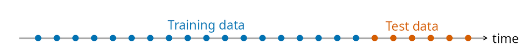

## Conjuntos de Teste e Treinamento

**Tamanho**

- O tamanho do conjunto de testes é normalmente de cerca de 20%/25% da amostra total.
- Idealmente, o conjunto de testes deve ser pelo menos tão grande quanto o horizonte máximo de previsão necessário.

## Trade-off entre Viés e Variância

**Overfitting e Underfitting**

- Um modelo que se ajusta bem nos dados de treinamento não necessariamente prevê bem.
- Um ajuste perfeito sempre pode ser obtido usando um modelo com parâmetros suficientes — mas isso geralmente **piora** as previsões.
- A **adaptação exagerada** (*overfitting*) ocorre quando o modelo captura ruído em vez de padrão: viés baixo, variância alta.
- A **simplificação excessiva** (*underfitting*) ocorre quando o modelo ignora estrutura real dos dados: viés alto, variância baixa.
- O objetivo é encontrar o equilíbrio: um modelo complexo o suficiente para capturar os padrões, mas simples o suficiente para generalizar para dados novos. Os critérios de informação (AIC, AICc, BIC) ajudam nessa escolha ao penalizar a complexidade.

## Funções para Dividir Séries Temporais

**Função `dplyr::filter()`**

A função `filter()` é útil ao extrair uma parte de uma série temporal, como precisamos ao criar conjuntos de treinamento e teste:

```r
# Filtra para dados a partir de 1992
producao_recente <- aus_production |>
  filter(year(Quarter) >= 1992)

# Cria conjunto de treinamento (dados até 2007)
treino <- producao_recente |>
  filter(year(Quarter) <= 2007)

# Cria conjunto de teste (dados após 2007)
teste <- producao_recente |>
  filter(year(Quarter) > 2007)

# Dimensões do conjunto de treino:
nrow(treino)
```

```
[1] 64
```

```r
# Dimensões do conjunto de teste:
nrow(teste)
```

```
[1] 10
```

## Erros de Previsão

**Descrição**

- Um **erro de previsão** é a diferença entre um valor observado e a previsão correspondente:

$$e_{T+h} = y_{T+h} - \hat{y}_{T+h|T}$$

sendo:

- $e_{T+h}$ o erro de previsão no horizonte $h$;
- $y_{T+h}$ o valor observado no tempo $T+h$;
- $\hat{y}_{T+h|T}$ a previsão feita no tempo $T$ para $y_{T+h}$.

## Erros de Previsão

**Descrição**

Os erros de previsão diferem dos **resíduos** em dois aspectos:

1. **Conjunto de dados**: resíduos são calculados no conjunto de treinamento; erros de previsão, no conjunto de teste.
2. **Horizonte**: resíduos baseiam-se em previsões um passo à frente; erros de previsão podem envolver múltiplos passos.

Para avaliar a precisão das previsões, resumimos os erros utilizando diferentes métricas.

## Erros Dependentes da Escala

**MAE e RMSE**

Estas métricas estão na mesma escala dos dados — por isso, **não permitem comparar previsões entre séries com escalas ou unidades diferentes**.

- **MAE** (*Mean Absolute Error*): média dos erros absolutos.

$$\text{MAE} = \frac{1}{h} \sum_{i=1}^{h} |y_{T+i} - \hat{y}_{T+i|T}|$$

- **RMSE** (*Root Mean Squared Error*): raiz da média dos erros ao quadrado.

$$\text{RMSE} = \sqrt{\frac{1}{h} \sum_{i=1}^{h} (y_{T+i} - \hat{y}_{T+i|T})^2}$$

Minimizar o MAE leva a previsões da **mediana**; minimizar o RMSE leva a previsões da **média**. O RMSE penaliza erros grandes mais fortemente.

## Erro Percentual

**MAPE**

O **MAPE** (*Mean Absolute Percentage Error*) expressa o erro em termos percentuais, permitindo comparar previsões em **diferentes escalas e unidades**.

$$\text{MAPE} = \frac{1}{h} \sum_{i=1}^{h} \left| \frac{y_{T+i} - \hat{y}_{T+i|T}}{y_{T+i}} \right| \times 100$$

Um MAPE de 5% significa que, em média, as previsões erram 5% em relação aos valores observados.

**Limitação**: o MAPE é indefinido quando $y_t = 0$ e assume valores extremos quando $y_t$ está próximo de zero.

## Erros Escalonados

**MASE (*Mean Absolute Scaled Error*)**

Proposto por Hyndman e Koehler (2006), o MASE permite comparar previsões entre séries com escalas e unidades diferentes.

A ideia é escalar o erro de previsão pelo MAE da previsão ingênua (*naïve*) calculada no conjunto de treinamento:

$$q_j = \frac{e_j}{\frac{1}{T-1} \sum_{t=2}^{T} |y_t - y_{t-1}|}$$

Para séries **sazonais**, o denominador usa a previsão sazonal ingênua:

$$q_j = \frac{e_j}{\frac{1}{T-m} \sum_{t=m+1}^{T} |y_t - y_{t-m}|}$$

O MASE é a média dos valores absolutos escalonados:

$$\text{MASE} = \text{média}(|q_j|)$$

**Interpretação**:

- $\text{MASE} < 1$: o modelo erra menos que a previsão ingênua *in-sample* (referência de escala).
- $\text{MASE} > 1$: o modelo erra mais que essa referência — comum em previsões fora da amostra.
- Para **comparar modelos**: menor MASE = melhor previsão.

## Modelos de referência (*benchmarks*)

**Previsões simples para comparação**

Para avaliar se um modelo sofisticado é realmente útil, comparamos suas previsões com as de modelos simples (*benchmarks*):

| Modelo | Função | Previsão |
| --- | --- | --- |
| Média | `MEAN()` | Média histórica da série |
| Naïve | `NAIVE()` | Último valor observado |
| Naïve sazonal | `SNAIVE()` | Último valor do mesmo período sazonal |
| Drift | `RW(~ drift())` | Último valor + tendência linear entre o primeiro e o último ponto |

Se um modelo ARIMA ou SARIMA não supera esses benchmarks, ele não está capturando estrutura útil além do que a simples repetição ou a média já oferecem.

O **SNAIVE** é o benchmark mais relevante para séries com sazonalidade: ele prevê que o próximo trimestre será igual ao mesmo trimestre do ano anterior.

# Exemplo 1

```r
# Primeiro, filtra para dados recentes (a partir de 1992)
producao_recente <- aus_production |>
  filter(year(Quarter) >= 1992)

# Cria conjunto de treinamento (dados até 2007)
treino <- producao_recente |>
  filter(year(Quarter) <= 2007)

# Cria conjunto de teste (dados após 2007)
teste <- producao_recente |>
  filter(year(Quarter) > 2007)

# Ajusta os modelos usando o conjunto de treino
modelos_fit <- treino |>
  model(
    Mean = MEAN(Beer),
    `Naïve` = NAIVE(Beer),
    `Seasonal naïve` = SNAIVE(Beer),
    Drift = RW(Beer ~ drift())
  )

# Gera previsões para todo o período de teste
previsoes <- modelos_fit |>
  forecast(h = nrow(teste))

# Cria um gráfico das previsões e dos dados atuais
previsoes |>
  autoplot(
    aus_production |> filter(year(Quarter) >= 1992),
    level = NULL
  ) +
  labs(
    y = "Megalitros",
    title = "Previsões para Produção Trimestral de Cerveja"
  ) +
  guides(colour = guide_legend(title = "Previsão"))
```

# Exemplo 1

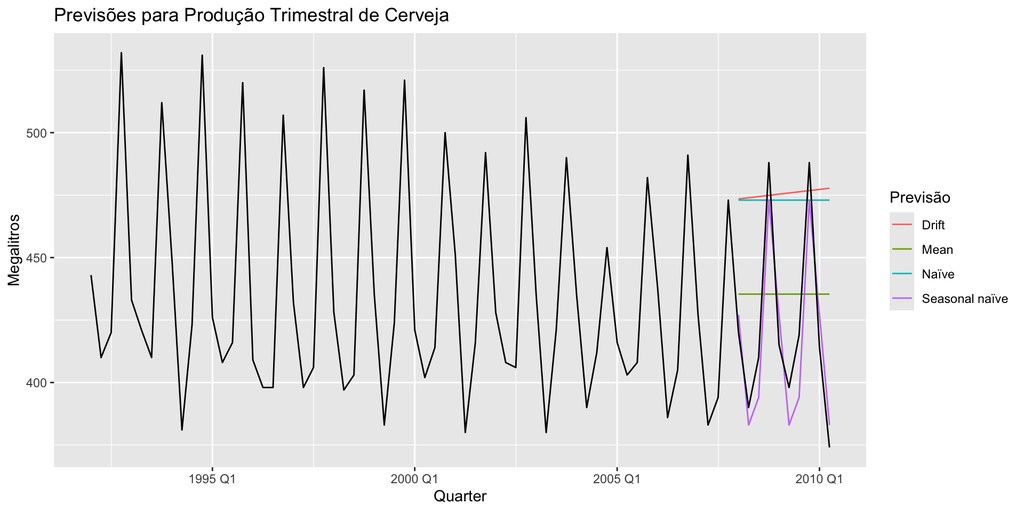

## Exemplo 1

```r
# Calcula as métricas de precisão
accuracy(previsoes, teste)
```

```
# A tibble: 4 × 10
  .model         .type    ME  RMSE   MAE    MPE  MAPE  MASE RMSSE    ACF1
  <chr>          <chr> <dbl> <dbl> <dbl>  <dbl> <dbl> <dbl> <dbl>   <dbl>
1 Drift          Test  -54.0  64.9  58.9 -13.6  14.6    NaN   NaN -0.0741
2 Mean           Test  -13.8  38.4  34.8  -3.97  8.28   NaN   NaN -0.0691
3 Naïve          Test  -51.4  62.7  57.4 -13.0  14.2    NaN   NaN -0.0691
4 Seasonal naïve Test    5.2  14.3  13.4   1.15  3.17   NaN   NaN  0.132
```

## O que são os modelos ETS?

**Suavização Exponencial em Espaço de Estados**

Os modelos **ETS** (*Error, Trend, Seasonality*) decompõem uma série temporal em três componentes:

- **Nível** ($\ell_t$) — o valor base da série no instante $t$;
- **Tendência** ($b_t$) — a direção e velocidade de crescimento (ou queda);
- **Sazonalidade** ($s_t$) — o padrão cíclico que se repete em intervalos regulares (trimestres, meses etc.).

A cada nova observação, os componentes são **atualizados** dando mais peso às observações recentes e menos peso às mais antigas — daí o nome *suavização exponencial*.

## O que são os modelos ETS?

**A sigla ETS**

**E**rror, **T**rend, **S**easonality — cada letra indica como o respectivo componente entra no modelo: de forma **A**ditiva, **M**ultiplicativa ou está ausente (**N**, *none*).

## Aditivo vs. Multiplicativo

**Quando usar cada tipo?**

A escolha entre aditivo e multiplicativo depende de como o componente se relaciona com o **nível** da série:

| Tipo | Comportamento | Quando usar |
| --- | --- | --- |
| **Aditivo (A)** | O efeito tem magnitude **constante** ao longo do tempo | Flutuações sazonais de tamanho aproximadamente fixo (ex: ±50 megalitros todo verão) |
| **Multiplicativo (M)** | O efeito é **proporcional** ao nível da série | Flutuações sazonais que crescem (ou diminuem) junto com o nível (ex: vendas sobem 20% todo dezembro) |
| **Nenhum (N)** | Componente ausente | Série sem tendência ou sem sazonalidade |

## Aditivo vs. Multiplicativo

**Regra prática**

Se a amplitude das oscilações sazonais **aumenta** quando a série sobe → sazonalidade **multiplicativa**. Se a amplitude permanece **estável** → sazonalidade **aditiva**.

## A notação `ETS(E, T, S)`

**Especificação dos componentes**

A notação `ETS(E, T, S)` indica a forma de cada componente:

| Posição | Componente | Opções |
| --- | --- | --- |
| 1ª | **Erro** | A (aditivo) ou M (multiplicativo) |
| 2ª | **Tendência** | N, A, ou A com amortecimento (Ad) |
| 3ª | **Sazonalidade** | N, A, ou M |

Exemplos usados nesta aula:

| Modelo | Erro | Tendência | Sazonalidade | Interpretação |
| --- | --- | --- | --- | --- |
| `ETS(A,A,A)` | Aditivo | Aditiva | Aditiva | Flutuações sazonais constantes, tendência linear |
| `ETS(M,A,M)` | Multiplicativo | Aditiva | Multiplicativa | Flutuações sazonais proporcionais ao nível |

## Modelos ETS

**Seleção automática**

- Quando não especificamos os componentes — `ETS(Beer)` —, R ajusta todos os modelos possíveis e seleciona o melhor pelo **AICc**, o mesmo critério usado na seleção de modelos ARIMA.

## Outros Modelos

```r
# Primeiro, filtra para dados recentes (a partir de 1992)
producao_recente <- aus_production |>
  filter(year(Quarter) >= 1992)

# Cria conjunto de treinamento (dados até 2007)
treino <- producao_recente |>
  filter(year(Quarter) <= 2007)

# Cria conjunto de teste (dados após 2007)
teste <- producao_recente |>
  filter(year(Quarter) > 2007)

# Ajusta os modelos usando o conjunto de treino
modelos_fit_outros <- treino |>
  model(
    `ETS(A,A,A)` = ETS(Beer ~ error("A") + trend("A") + season("A")),
    `ETS(M,A,M)` = ETS(Beer ~ error("M") + trend("A") + season("M")),
    `ARIMA(2,1,2)` = ARIMA(Beer ~ pdq(2,1,2)),
    `SARIMA(1,1,1)(1,1,1)` = ARIMA(Beer ~ pdq(1,1,1) + PDQ(1,1,1))
  )

# Gera previsões para todo o período de teste
previsoes_outros <- modelos_fit_outros |>
  forecast(h = nrow(teste))

# Cria um gráfico das previsões e dos dados atuais
previsoes_outros |>
  autoplot(
    aus_production |> filter(year(Quarter) >= 1992),
    level = NULL
  ) +
  labs(
    y = "Megalitros",
    title = "Previsões para Produção Trimestral de Cerveja"
  ) +
  guides(colour = guide_legend(title = "Previsão"))
```

## Outros Modelos

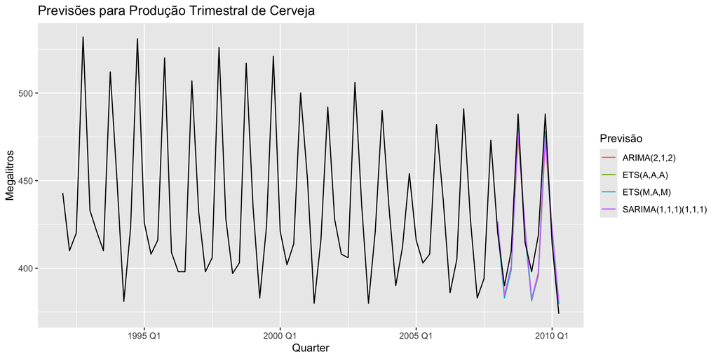

## Outros Modelos

```r
# Calcula as métricas de precisão
accuracy(previsoes_outros, teste)
```

```
# A tibble: 4 × 10
  .model               .type    ME  RMSE   MAE   MPE  MAPE  MASE RMSSE  ACF1
  <chr>                <chr> <dbl> <dbl> <dbl> <dbl> <dbl> <dbl> <dbl> <dbl>
1 ARIMA(2,1,2)         Test   5.70  12.2 10.8  1.28   2.54   NaN   NaN 0.129
2 ETS(A,A,A)           Test   5.36  10.8  9.47 1.23   2.25   NaN   NaN 0.188
3 ETS(M,A,M)           Test   5.95  10.8  8.99 1.38   2.14   NaN   NaN 0.228
4 SARIMA(1,1,1)(1,1,1) Test   4.25  11.5 10.6  0.944  2.51   NaN   NaN 0.144
```

## Validação-Cruzada para Séries Temporais

**Por que ir além do split treino/teste?**

Com um único split, a avaliação da acurácia depende de **um único ponto de corte**. A validação cruzada resolve isso usando **múltiplas origens de previsão**:

1. Começa-se com um conjunto de treino mínimo e gera-se uma previsão para a próxima observação.
2. Incorpora-se essa observação ao treino e repete-se o processo.
3. A cada passo, a **origem da previsão** avança uma posição no tempo.

O erro final é a **média dos erros** sobre todas essas origens.

Como o treino inicial pode ser pequeno demais para produzir previsões confiáveis, as primeiras observações não são usadas como conjunto de teste.

## Validação cruzada: previsão 1 passo à frente

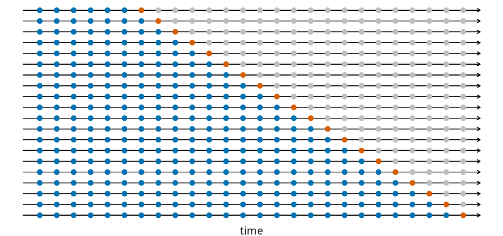

Validação cruzada com origem móvel: a cada iteração, o conjunto de treino cresce em uma observação e gera-se uma previsão para o próximo ponto. A acurácia é a média dos erros sobre todas as origens.

## Validação cruzada: previsão com horizonte $h > 1$

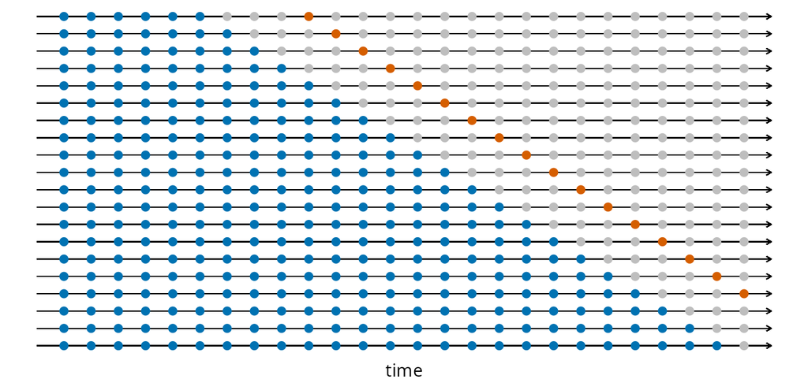

Variante para horizontes maiores: em vez de prever apenas 1 passo, cada origem gera previsões para $h$ passos à frente. Aqui, $h = 4$. A acurácia é calculada para cada horizonte separadamente.

## Seleção de Modelos de Previsão via Validação-Cruzada

**Exemplo**

O exemplo a seguir aplica validação cruzada à série de preços de fechamento das ações do Google em 2015, em cinco etapas:

1. **Prepara os dados**: seleciona a ação GOOG e cria um índice diário regular.
2. **Constrói as origens de previsão**: a função `stretch_tsibble()` gera múltiplos conjuntos de treino crescentes — cada um com uma observação a mais que o anterior. É ela que operacionaliza a validação cruzada.
3. **Ajusta e prevê**: para cada origem, estima um passeio aleatório com *drift* e gera uma previsão 1 passo à frente.
4. **Calcula a acurácia via CV**: `accuracy()` compara as previsões com os valores observados, calculando a média dos erros sobre todas as origens.
5. **Compara com a acurácia sem CV**: estima o mesmo modelo nos dados completos e calcula a acurácia dos resíduos — para mostrar que os resultados diferem.

## Exemplo: preparação dos dados

```r
# Filtra os dados da ação do Google (GOOG) a partir de 2015
# Cria uma coluna 'day' com números sequenciais para cada dia de negociação
# Atualiza o objeto para um tsibble usando 'day' como índice
google_stock <- gafa_stock |>
  filter(Symbol == "GOOG", year(Date) >= 2015) |>
  mutate(day = row_number()) |>
  update_tsibble(index = day, regular = TRUE)

# Filtra apenas os dados do ano de 2015 para análise
google_2015 <- google_stock |> filter(year(Date) == 2015)
```

## Exemplo: origens de previsão com `stretch_tsibble()`

```r
# Cria múltiplas amostras de treinamento crescentes
# .init = 3: começa com 3 observações
# .step = 1: aumenta uma observação por vez
google_2015_tr <- google_2015 |>
  stretch_tsibble(.init = 3, .step = 1) |>
  relocate(Date, Symbol, .id)

# Mostra o resultado da preparação
google_2015_tr
```

[output not shown]

## Exemplo: acurácia via CV vs. acurácia simples

```r
# Validação cruzada: ajusta passeio aleatório com drift em cada origem,
# gera previsão 1 passo à frente e calcula a acurácia média
google_2015_tr |>
  model(RW(Close ~ drift())) |>
  forecast(h = 1) |>
  accuracy(google_2015)

# Sem validação cruzada: acurácia dos resíduos nos dados completos
google_2015 |>
  model(RW(Close ~ drift())) |>
  accuracy()
```

[output not shown]

## Custo computacional da validação cruzada

**Quantos ajustes de modelos são necessários?**

Na validação cruzada, cada **origem de previsão** exige um ajuste completo do modelo. O número total de ajustes é:

$$N_{\text{ajustes}} = \frac{T - n_{\min}}{\text{step}} \times M$$

em que $T$ é o tamanho da série, $n_{\min}$ o tamanho inicial do treino (`.init`), `step` o incremento (`.step`) e $M$ o número de modelos.

| Cenário | $T$ | `.init` | `.step` | Modelos | Ajustes |
| --- | --- | --- | --- | --- | --- |
| Google (slides) | 252 | 3 | 1 | 1 | $(252-3)/1 \times 1 = 249$ |
| Gas (exercício) | 218 | 40 | 1 | 2 | $(218-40)/1 \times 2 = 356$ |
| Gas (reduzido) | 218 | 40 | 4 | 2 | $(218-40)/4 \times 2 \approx 90$ |

Modelos ARIMA são mais custosos que RW ou SNAIVE. Em notebooks com recursos limitados, prefira **`.step` maior** (ex: 4 para séries trimestrais) ou **use apenas modelos com especificação fixa** (`stepwise = TRUE`), evitando busca exaustiva dentro da CV.

## Divisão fixa vs. validação cruzada

**Síntese**

- A **divisão treino/teste fixa** é simples e rápida, mas a estimativa da acurácia depende de um **único ponto de corte** — que é, em certa medida, arbitrário.
- A **validação cruzada** produz uma estimativa mais **confiável** da acurácia preditiva, porque calcula a média dos erros sobre múltiplas origens de previsão, reduzindo a variância da estimativa.
- A CV **não garante** selecionar um modelo diferente do split fixo — sua vantagem é dar **maior confiança** de que o erro reportado reflete o desempenho real do modelo.
- O custo computacional cresce com o número de origens e com a complexidade dos modelos, mas pode ser controlado:
  - aumentando `.step` (ex: `.step = 4` para séries trimestrais);
  - usando modelos com especificação fixa em vez de busca automática.
- Na prática, modelos simples (SNAIVE, RW) podem ser avaliados via CV mesmo em computadores modestos. Para modelos ARIMA com busca exaustiva, o split fixo continua sendo uma alternativa válida.

# Exercício

## Exercício

**Objetivo**

Aplicar o ciclo completo da metodologia de Box & Jenkins a um modelo SARIMA, com ênfase na **avaliação da acurácia preditiva** fora da amostra.

## Exercício

**Série utilizada**

A série `Gas` do conjunto de dados `aus_production`, disponível no pacote `fpp3`, registra a **produção trimestral de gás na Austrália**, em petajoules, de 1956 a 2010.

A série apresenta:

- tendência crescente acentuada;
- forte sazonalidade anual ($m = 4$);
- variabilidade que cresce com o nível da série.

## Exercício:

**Itens 1–5**

1. **Análise exploratória**: visualize a série original e avalie se uma transformação logarítmica é recomendável.
2. **Diferenciação**: aplique diferença sazonal ($m = 4$). Se necessário, aplique também uma diferença simples. Visualize com `gg_tsdisplay()`.
3. **Identificação**: com base na FAC e FACP, proponha pelo menos **dois** modelos SARIMA candidatos.
4. **Estimação e seleção**: estime os modelos candidatos e um modelo automático. Compare via AICc.
5. **Diagnóstico**: verifique se os resíduos do modelo selecionado são compatíveis com ruído branco.

## Exercício

**Item 6 — Avaliação da acurácia preditiva**

- Divida a série em **treino** (até 2004) e **teste** (2005 em diante).
- Estime o modelo selecionado e um **SNAIVE** (benchmark sazonal) usando apenas os dados de treino.
- Gere previsões para o horizonte do conjunto de teste.
- Calcule **MAE**, **RMSE**, **MAPE** e **MASE** para cada modelo.
- Interprete: compare os valores de MASE entre os dois modelos. O modelo com menor MASE tem melhor acurácia. O SARIMA supera o SNAIVE?

## Referências

BOX, G. E. P.; JENKINS, G. M. **Time Series Analysis: Forecasting and Control**. San Francisco: Holden-Day, 1970.

BROOKS, C. **Introductory Econometrics For Finance**. 4th. ed. [s.l.] Cambridge University Press, 2019.

HILL, R. C.; GRIFFITHS, W. E.; JUDGE, G. G. **Econometria**. 3. ed. São Paulo: Saraiva, 2003.

HYNDMAN, R. J.; ATHANASOPOULOS, G. **[Forecasting: Principles and Practice](https://otexts.com/fpp3/)**. 3. ed. Melbourne, Australia: OTexts, 2021.

HYNDMAN, R. J.; KOEHLER, A. B. [Another Look at Measures of Forecast Accuracy](https://doi.org/10.1016/j.ijforecast.2006.03.001). **International Journal of Forecasting**, v. 22, n. 4, p. 679–688, 2006.

MORETTIN, P. A. **Econometria Financeira: um curso em séries temporais e financeiras**. 2. ed. São Paulo: Edgard Blücher, 2011.

WOOLDRIDGE, J. M. **Introdução à Econometria: Uma Abordagem Moderna**. Traducao Flávio E. F. Marques. 5. ed. São Paulo, Brasil: Cengage Learning, 2016.